# Visualization functions

## Interpreting PCoA

PCoA plots are interesting but tricky to interpret, let’s have a look at them.

A PCoA plot contains a single point for each individual, and the closer two points are, the more similar these individuals are. Generally, the sign and dimensions of the axis are meaningless, so there is no need to worry about them. That also means that two mirrored images in a PCoA are equivalent. It is crucial, as well, to look carefully at the percentage of explained variance of each PC, as this is an indication of the relative importance of that axis in comparison to the original genotype matrix. Let’s look at the PCoA plots above.

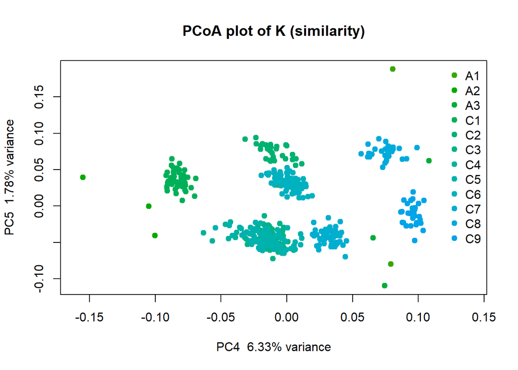

```r
pcoa.plot(K,col = pop,legpos = "topright",xlim = c(-0.16,0.14),comp = c(4,5),
          pch=19,main="PCoA plot of K (similarity)")
```

We feel tempted to try to interpret this plot’s seemingly interesting structure, however, the percentage of explained variance of each axis is so small, that the distribution of points in this plane is likely to be meaningless.

Although this might seem obvious here, there are many scientific papers where, aiming to support their original hypothesis, very unclear PCoA plots are over-interpreted without any statistical solidity, leading to weakly supported claims. A good rule of thumb for PCoA plots then, is to always look for high variance components and for **clear patterns**, rather than obscure interpretations of abstract shapes.

# P-value visualization

In a QTL analysis some type of significance score is obtained along the genome, either continuously (typically LOD scores) or at discrete marker positions (typically a p-value). In the model implemented in `mpQTL`, significances are expressed as p-values, discretely along the genome. We can study the p-values in two different ways: looking at their overall distribution using Quantile-Quantile plots (QQ-plot) or plotting the significance scores along the genomic map (Manhattan plot, skyline plot in `mpQTL`).

## Quantile-Quantile plot

QQ-plots are useful for determining whether the p-value distribution of a QTL analysis (y axis) follows the expected distribution (x axis). In this case, the expected distribution corresponds to a null hypothesis where there are **no truly significant markers** (there are only a few false positives). This expectation can be seen in the plot with a red diagonal line.

### The function

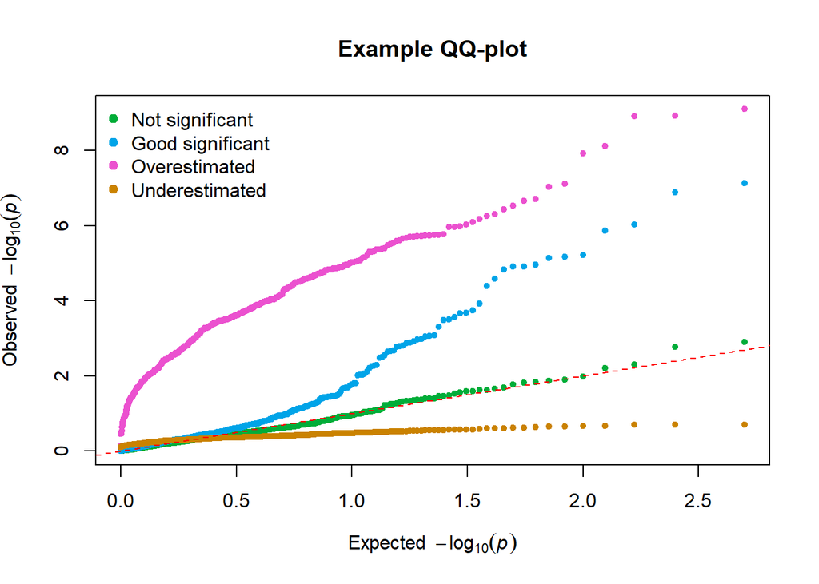

```r
#The p-values are from 500 random normal values
not_sig <- pnorm(rnorm(500),lower.tail = F)

#The p-values are from some random normal values and some non-random
some_sig <- pnorm(c(rnorm(450),rnorm(50,mean = 3)),lower.tail = F)

#The p-values are all too significant
high_sig <- pnorm(rnorm(500,mean=3),lower.tail = F)

#The p-values are all too non-significant
low_sig <- pnorm(rnorm(500),sd = 3,lower.tail = F)

pvals <- list(not_sig,some_sig,high_sig,low_sig)
QQ.plot(pvals,main="Example QQ-plot",
        legnames = c("Not significant",
                     "Good significant",
                     "Overestimated",
                     "Underestimated"))
```

A *legend* is automatically added, but can be deactivated using the argument `plot_legend = F`, and the legend names are extracted from the column names or list element names. In case no names are provided, they’re labelled as “pval 1”, “pval 2”, etc. This can also be changed with the argument `legname` and giving a vector of names.

### Interpreting QQ plots

Our aim when looking at a QQ plot is to evaluate whether the p-values follow an expected p-value distribution, and if they don’t, evaluate whether the deviations are due to modelling problems or the detection of a QTL. Above we have plotted four situations, let’s have a look at them:

Lastly, we might be able to apply multiple models to the same data (for instance, including extra cofactors), producing different results. We are then forced to choose which model to trust, which might be difficult if there are no obvious differences between the models suitability. We might then use QQ plots to compare the distributions of multiple models to evaluate whether we are in one of the previously described scenarios with any of the models.

## Skyline plot

Probably the most relevant plot for QTL mapping is the “Manhattan plot”, named as such due to its structure, which can remind of the skyline of of the famous skyscraper district of New York. In this package, we have opted to name the function `skyplot()`, following the visual metaphor.

A Manhattan plot is a form of marker significance visualization that helps us recognise regions where multiple significant markers co-locate around a region, defining a QTL location. On the x-axis the marker’s position in the genome (physical or genetic) and on the y-axis, the marker’s significance. Generally, significance is expressed as $-log10(pval)$, but any other score will do, as long as it follows that more significant markers have higher scores, and less significant markers have lower scores (for instance a Wald score or F-test).

### The function

To generate the visualization one must provide both p-values and a genetic/physical map. The `skyplot()` function has the following arguments:

- `pval`: vector of pvalues. Importantly, the function `-log10()` must be performed by the user. This has been done on purpose, as we might want to plot other kind of score values with this function that do not require the -log10 transformation.
- `map`: a genetic map data.frame with at least columns “position” and “chromosome”.
- `threshold`: numeric, optional value to draw a threshold line.
- `chrom`: numeric or character vector. If provided, it is used to select the p-values based on the “chromosome” column of `map`.
- `small`: logical, should the cM scale be drawn? By default it will only be drawn if only two or a single chromosome are plotted, otherwise it is too crowded and barely legible.
- `...`: other parameters can be passed to the `plot()` function. The most relevant are probably `main` for the title, `ylab` for the label on the y axis and `xlab` for the label of the x axis.

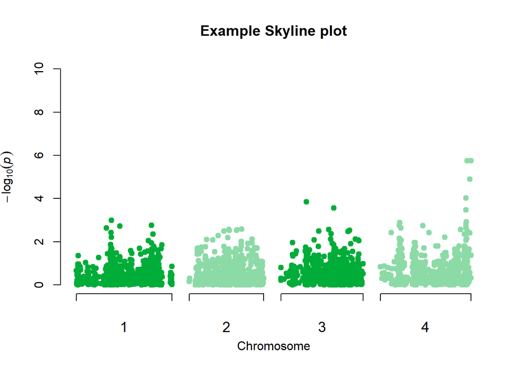

```r
#Just a skyline plot
skyplot(-log10(pv),map = map,main="Example Skyline plot")
```

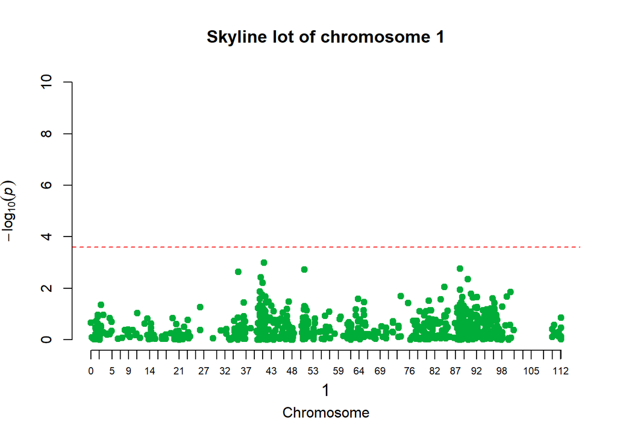

```r
#We want to focus on chromosome 1
skyplot(-log10(pv),map,chrom = 1,main ="Skyline lot of chromosome 1",threshold = 3.6)
```

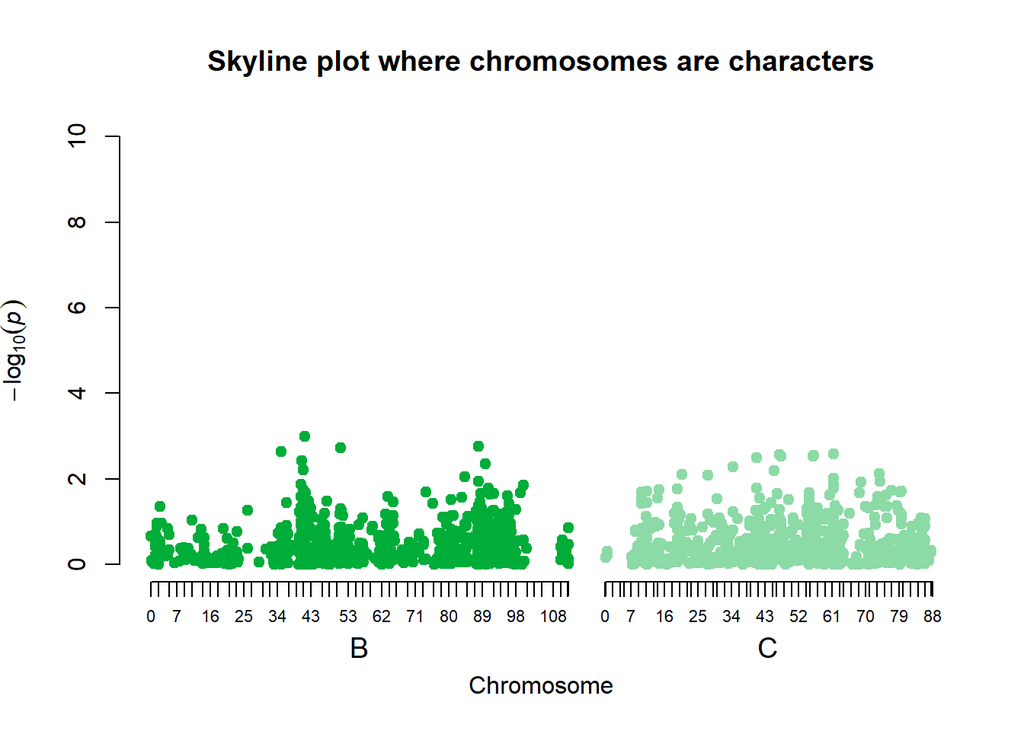

```r
#The "chromosomes" can also be expressed as characters
map_letters <- map
map_letters$chromosome <- LETTERS[map_letters$chromosome + 1]

skyplot(-log10(pv),map_letters,main="Skyline plot where chromosomes are characters",
        chrom = sample(unique(map_letters$chromosome),2),small = T)
```

For our research, we wanted to compare the skyline plots of multiple models, namely the haplotype-based and dosage-based models. For that reason, another skyline plot function was developed: `comp.skplot()`. The function is used in a very similar fashion, with some differences:

- `pval`: each p-value vector must be provided as a column in a matrix or a vector in a list.
- `map`: a map must be provided for each set of p-values. If a single map is provided, it will be assumed that all p-value vectors correspond to the same map. For the moment, we have not tested what happens if each map has a different set of chromosomes (i.e. map1 has chromosomes 1, 2 and 3 and map2 has chromosomes 1, 2 and 4), that might cause conflicts.
- `chrom`: similarly, we have not tested what would happen if chromosomes are selected that are present only in one of the two maps. This will be looked into.
- `legnames`: a vector of names for the legend elements. If not provided, it will be read from the pvalue list, and if the list has no names, it will be simply labelled pval 1, pval 2, etc.

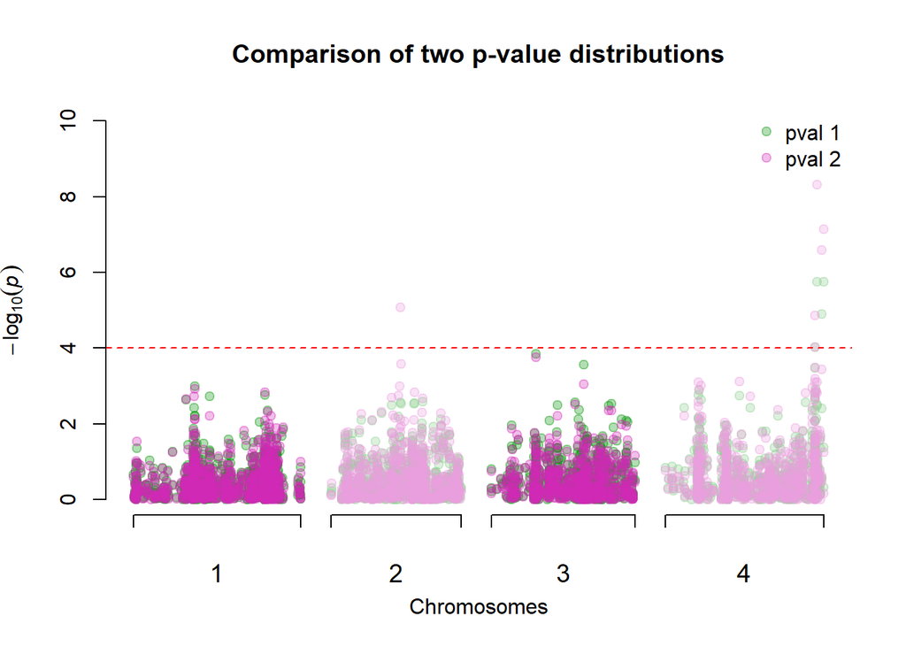

```r
pv2 <- data$result[[2]]$pval

comp.skyplot(list(-log10(pv),-log10(pv2)),map,main = "Comparison of two p-value distributions",threshold = 4)
```

### Interpreting skyline plots

Skyline plots are very easy to interpret since they are so intuitively eloquent. The higher the peak, the more significant a marker/region is, the stronger the QTL effect must be on the trait in question.

To define a **QTL region** we use a threshold, which for the moment we are calculating using a permutation threshold, which accounts for multiple testing. All markers above the threshold should be considered significant, and thus we can define a QTL region in every place where a series of close markers are above the threshold.

One can **compare skyline plots** between different phenotypes to see if the same or similar region are detected using different phenotypes, since that might indicate that a single QTL has effect on both traits.

# Phenotype boxplot

### The function

There is a single function, `pheno_box()` that can use two different methods, either for dosages or for haplotypes, by changing the parameter `haplotype` (False by default). Some parameters behave identically no matter what the value of `haplotype` is:

- `phe`: is a numerical vector of phenotypes
- `gen`: if haplotype = F, `gen` should be a numeric vector of dosages with a single observation per individual. If haplotype = T, `gen` should be a vector with $p$ numeric/character observations per individual where $p$ is the ploidy, and each observation is a haplotype class (e.g. 120, 140, 128…;A, B, C…; hap1, hap2, hap3…)
- `draw.points`: is a logical that indicates whether points should be drawn.
- `...`: further arguments to be passed to `plot()`

When `haplotype = T` other parameters can be used: * `ploidy`: is an integer indicating the ploidy. * `hap.select`: is a vector of numeric/character indicating which haplotypes should be plotted.

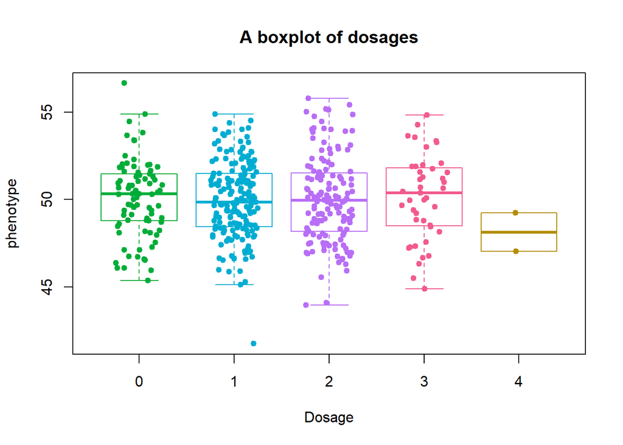

```r
gen_dos <- unlist(dos[4,])
gen_hap <- unlist(hap[4,])

pheno_box(phe[,1],gen_dos,
          xlab="Dosage",ylab="phenotype",main="A boxplot of dosages")
```

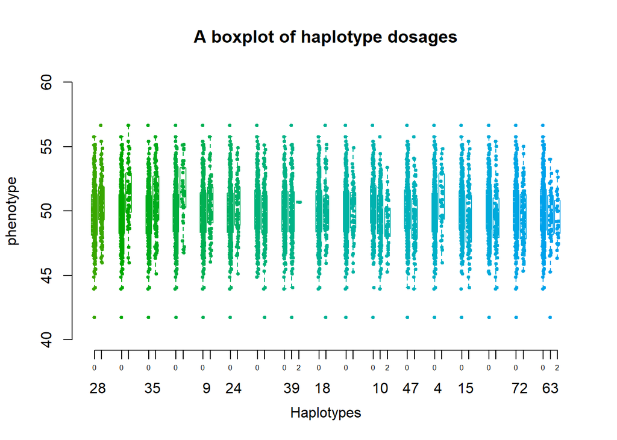

```r
#But now there are too many things plotted and I can't see anything
pheno_box(phe[,1],gen_hap,haplotype = T,ploidy = 4,
          xlab="Haplotypes",ylab="phenotype",main="A boxplot of haplotype dosages")
```

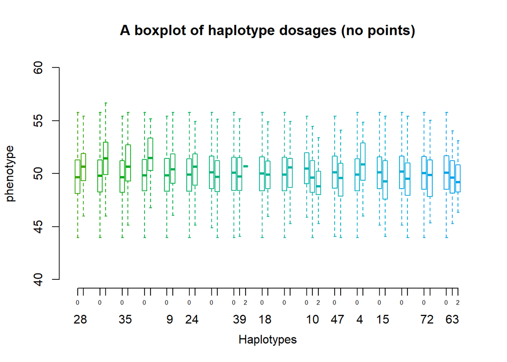

```r
#This is better but still too many boxes
pheno_box(phe[,1],gen_hap,haplotype = T,ploidy = 4,draw.points = F,
          xlab="Haplotypes",ylab="phenotype",main="A boxplot of haplotype dosages (no points)")
```

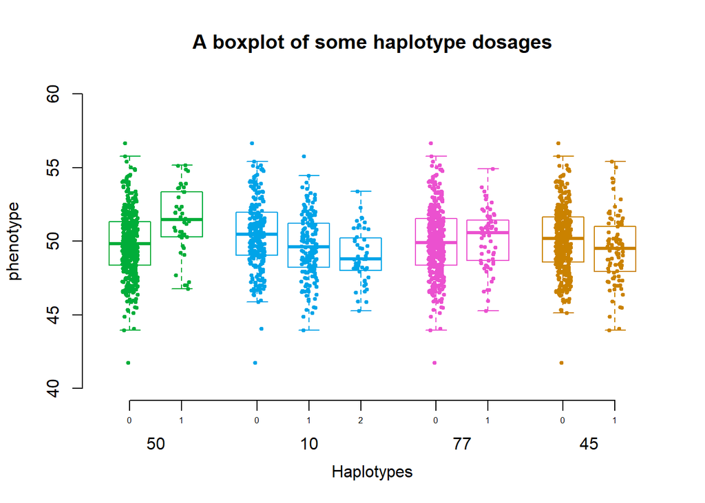

```r
#This is better
pheno_box(phe[,1],gen_hap,haplotype = T,ploidy = 4, hap.select = c(50,10,77,45),
          xlab="Haplotypes",ylab="phenotype",main="A boxplot of some haplotype dosages")
```

# Colour choice

The colour system of the visualization functions in the mpQTL package is a bit different than the default methods that most R plots include. To perform colour choice we use the package `colorspace`, which uses the HCL (hue, color tone; chrome, coloyr intensity; and luminance, colour lightness) system to define colour. This package has been designed with data visualization in mind and offers great functionalities for intelligent and effective colour choice. If you are interested, I highly recommend visiting their [web page](http://colorspace.r-forge.r-project.org/), where they explain the package and many important concepts of colour theory and design.

For our purposes, there are two main types of colour palettes we can make: **qualitative** or **sequential**. The first type of palette chooses different *hues* of colour (red, green, blue…) while the second one chooses different *luminances* (from dark to light) of the same hue. Additionally, **divergent** colour palettes can be used, which set middle values to white and extreme values to two opposing hues, allowing us to highlight extreme values. Which palette type whe choose will depend on the data we try to visualize:

- In *categorical variables* all categories are of equal importance, and thus a *qualitative* palette will be most useful. However, if there are more than 7 categories, it is advised to avoid qualitative palettes with many hues and instead use *sequential* palettes, since with 8 or more colours it is hard to keep track of all categories and distinguish all hues.
- With *numerical variables* that are ordered, *sequential* palettes, are the most useful. Our eyes will instinctively give the most importance to the darker colours, and thus these palettes are useful to highlight very high or very low values. Also, when there are many categories, sequential palettes can be used to avoid having many colours. If we are using values that can be very negative or very positive (like temperatures), *divergent* palettes might be the most useful.

There are other types of palettes that can be useful, but we will not discuss them here.

### The function

In all plotting functions, two extra parameters can be chosen:

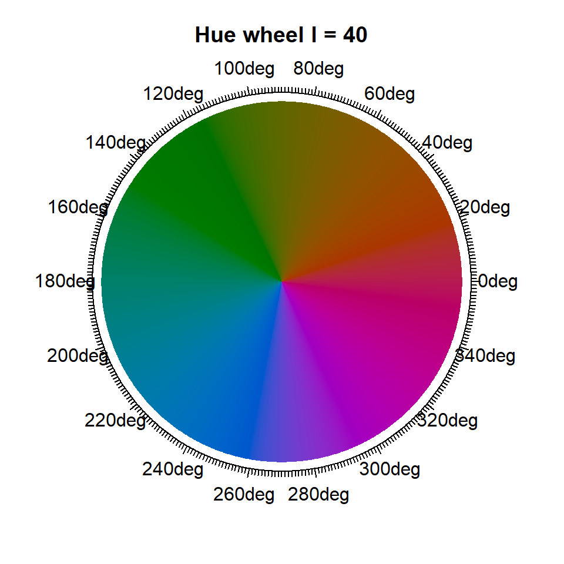

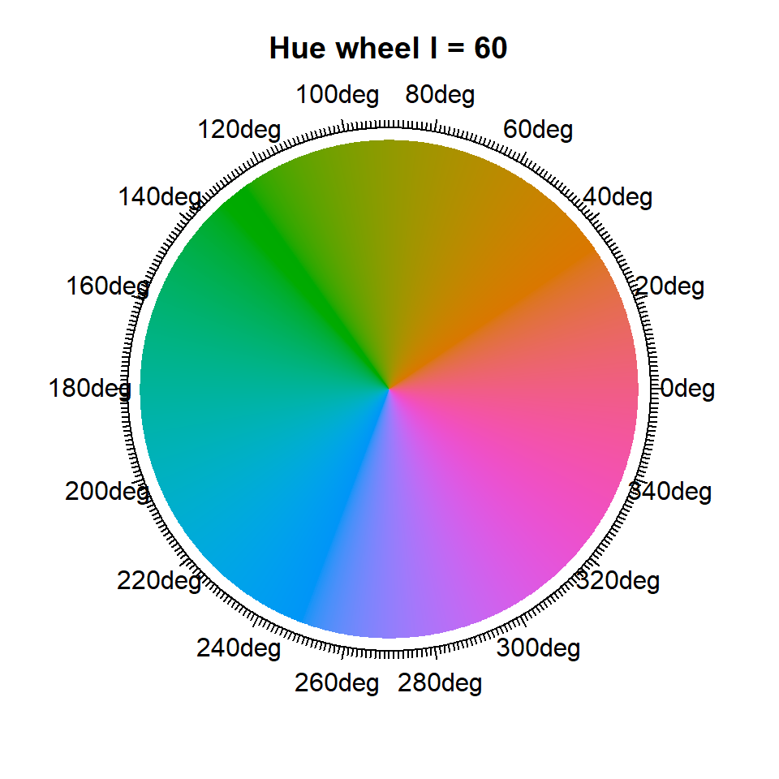

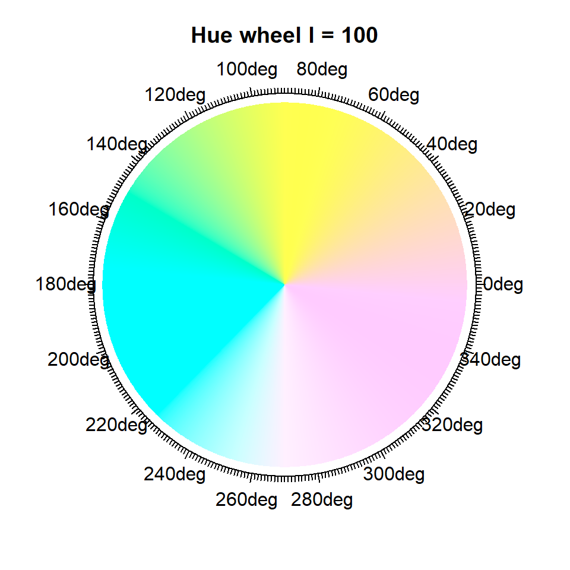

With this system, changing the colours of any plot is pretty straight-forward. You can specify a different pair of values for `h`, to create a gradient between these two colours (in qualitative palettes) or a single `h` for sequential palettes. To switch between sequential and qualitative palettes simply change the `coltype` parameter. If you would like a stronger light-dark contrast in sequential palettes, choose more extreme `l` values, `c(20,90)` by default, or if you would like less contrast, choose closer values. For qualitative palettes, you can use this parameter to obtain lighter, or darker colours.

As a final note, since the colours are expressed in degrees, 0, 360, 720 and 1080 all refer to the same hue: red. If you set a qualitative gradient between 0 and 10, the palette will start at red and end at a very similar red (so all colours will be very similar). If, instead, you give 0 and 370 as the `h` value, the colours will start and end at these reds, but going through the whole colour wheel, giving a sort-of rainbow palette.